# TB1: Análisis EDA - Hotel Booking Demand

Fundamentos de Data Science | Grupo 2

Grupo 2 - Integrantes: Chavez Pino, Paula Brenda | Macalupu Marchan, Yeissen Beckam | Quispe Valdez, Elim Zabdi | Cárdenas Cabrera, Ángel David

02/10/2026

# Objetivo y audiencia

El objetivo de este informe es realizar un análisis exploratorio del dataset **Hotel Booking Demand**, con énfasis en la duración de las estancias y en las características de las reservas que incluyen niños y/o bebés.

El análisis puede ser útil para áreas como **gerencia de operaciones**, **reservas**, **marketing** y **revenue management**, ya que permite comprender patrones de estancia, composición de huéspedes, cancelaciones y comportamiento temporal de las reservas.

## Preguntas analíticas

1. **¿Cómo se distribuye y compara la duración total de la estancia entre las reservas de City Hotel y Resort Hotel?**
2. **¿Qué características presentan las reservas con niños y/o bebés en relación con el tipo de hotel, duración de estancia, cantidad de adultos, tipo de cliente y cancelación?**

# Descripción del dataset

El archivo `hotel_bookings.csv` contiene información de reservas realizadas en **City Hotel** y **Resort Hotel**. Incluye variables relacionadas con cancelaciones, fechas de llegada, anticipación de la reserva, duración de la estancia, huéspedes, segmentos de mercado, tipo de cliente, tarifa diaria promedio y otras características de la reserva.

```r
archivo_datos <- "data/hotel_bookings.csv"

if (!file.exists(archivo_datos)) {
  stop("No se encontró el archivo data/hotel_bookings.csv. Verifique que el Rmd se ejecute desde la carpeta raíz del proyecto TB1.")
}

hotel <- read.table(
  archivo_datos,
  header = TRUE,
  sep = ",",
  dec = ".",
  na.strings = c("NA", "NULL"),
  stringsAsFactors = FALSE
)

dimensiones <- tibble(
  Registros = nrow(hotel),
  Variables = ncol(hotel)
)

kable(
  dimensiones,
  caption = "Dimensiones iniciales del dataset"
)
```

Dimensiones iniciales del dataset

| Registros | Variables |
| --- | --- |
| 119390 | 32 |

El dataset original contiene **119390 registros** y **32 variables**.

```r
muestra <- hotel |>
  select(
    hotel,
    is_canceled,
    lead_time,
    arrival_date_year,
    arrival_date_month,
    stays_in_weekend_nights,
    stays_in_week_nights,
    adults,
    children,
    babies,
    adr
  ) |>
  head(6)

kable(
  muestra,
  caption = "Muestra de registros del dataset"
)
```

Muestra de registros del dataset

| hotel | is_canceled | lead_time | arrival_date_year | arrival_date_month | stays_in_weekend_nights | stays_in_week_nights | adults | children | babies | adr |
| --- | --- | --- | --- | --- | --- | --- | --- | --- | --- | --- |
| Resort Hotel | 0 | 342 | 2015 | July | 0 | 0 | 2 | 0 | 0 | 0 |
| Resort Hotel | 0 | 737 | 2015 | July | 0 | 0 | 2 | 0 | 0 | 0 |
| Resort Hotel | 0 | 7 | 2015 | July | 0 | 1 | 1 | 0 | 0 | 75 |
| Resort Hotel | 0 | 13 | 2015 | July | 0 | 1 | 1 | 0 | 0 | 75 |
| Resort Hotel | 0 | 14 | 2015 | July | 0 | 2 | 2 | 0 | 0 | 98 |
| Resort Hotel | 0 | 14 | 2015 | July | 0 | 2 | 2 | 0 | 0 | 98 |

# Metodología y preparación de los datos

El análisis se desarrolló en cuatro etapas:

1. Revisión de **calidad de datos**: completitud, unicidad, consistencia, validez y exactitud cuando fue posible.
2. **Preparación y transformación** sin modificar el dataset original.
3. Análisis **univariado, bivariado, multivariado y temporal**.
4. Síntesis de **hallazgos, conclusiones, recomendaciones y limitaciones**.

## Calidad de los datos

```r
tabla_faltantes <- hotel |>
  summarise(
    across(
      everything(),
      ~ sum(is.na(.))
    )
  ) |>
  pivot_longer(
    cols = everything(),
    names_to = "Variable",
    values_to = "Faltantes"
  ) |>
  mutate(
    Porcentaje = round(
      Faltantes / nrow(hotel) * 100,
      2
    )
  ) |>
  filter(Faltantes > 0) |>
  arrange(desc(Faltantes))

kable(
  tabla_faltantes,
  caption = "Valores faltantes identificados en el dataset"
)
```

Valores faltantes identificados en el dataset

| Variable | Faltantes | Porcentaje |
| --- | --- | --- |
| company | 112593 | 94.31 |
| agent | 16340 | 13.69 |
| country | 488 | 0.41 |
| children | 4 | 0.00 |

Se identificaron valores faltantes principalmente en `company`, `agent`, `country` y `children`. Estos valores no fueron imputados de manera arbitraria.

```r
duplicados <- sum(duplicated(hotel))

reservas_sin_huespedes <- sum(
  hotel$adults +
    replace_na(hotel$children, 0) +
    hotel$babies == 0
)

adr_negativos <- sum(
  hotel$adr < 0,
  na.rm = TRUE
)

resumen_calidad <- tibble(
  Indicador = c(
    "Registros exactamente duplicados",
    "Reservas sin huéspedes",
    "Registros con ADR negativo"
  ),
  Cantidad = c(
    duplicados,
    reservas_sin_huespedes,
    adr_negativos
  )
)

kable(
  resumen_calidad,
  caption = "Principales problemas de calidad detectados"
)
```

Principales problemas de calidad detectados

| Indicador | Cantidad |
| --- | --- |
| Registros exactamente duplicados | 31994 |
| Reservas sin huéspedes | 180 |
| Registros con ADR negativo | 1 |

Se detectaron **31994 registros exactamente repetidos**, **180 reservas sin huéspedes** y **1 registro(s) con tarifa diaria promedio negativa**. La exactitud no pudo verificarse directamente debido a que no se dispone de una fuente externa o regla de negocio para contrastar los valores.

## Preparación y transformación

Se creó una nueva versión denominada `hotel_limpio`. El dataset original se conserva sin modificaciones.

```r
hotel_limpio <- hotel |>
  distinct() |>
  filter(
    adults +
      replace_na(children, 0) +
      babies > 0
  ) |>
  mutate(
    reservation_status_date = as.Date(
      reservation_status_date
    ),

    arrival_month_num = match(
      arrival_date_month,
      month.name
    ),

    arrival_date = make_date(
      arrival_date_year,
      arrival_month_num,
      arrival_date_day_of_month
    ),

    periodo = floor_date(
      arrival_date,
      unit = "month"
    ),

    total_nights =
      stays_in_weekend_nights +
      stays_in_week_nights,

    con_menores = case_when(
      children > 0 | babies > 0 ~ "Con niños/bebés",
      children == 0 & babies == 0 ~ "Sin niños/bebés",
      TRUE ~ NA_character_
    ),

    hotel = factor(hotel),

    arrival_date_month = factor(
      arrival_date_month,
      levels = month.name,
      ordered = TRUE
    ),

    is_canceled = factor(
      is_canceled,
      levels = c(0, 1),
      labels = c("No", "Sí")
    ),

    is_repeated_guest = factor(
      is_repeated_guest,
      levels = c(0, 1),
      labels = c("No", "Sí")
    ),

    meal = factor(meal),
    country = factor(country),
    market_segment = factor(market_segment),
    distribution_channel = factor(distribution_channel),
    reserved_room_type = factor(reserved_room_type),
    assigned_room_type = factor(assigned_room_type),
    deposit_type = factor(deposit_type),
    agent = factor(agent),
    company = factor(company),
    customer_type = factor(customer_type),
    reservation_status = factor(reservation_status),

    con_menores = factor(
      con_menores,
      levels = c(
        "Sin niños/bebés",
        "Con niños/bebés"
      )
    )
  )

dimensiones_preparadas <- tibble(
  Registros = nrow(hotel_limpio),
  Variables = ncol(hotel_limpio)
)

kable(
  dimensiones_preparadas,
  caption = "Dimensiones del dataset preparado"
)
```

Dimensiones del dataset preparado

| Registros | Variables |
| --- | --- |
| 87230 | 37 |

Después de la preparación, `hotel_limpio` contiene **87230 registros**.

# Resultados

## Duración de las estancias

```r
resumen_duracion <- hotel_limpio |>
  summarise(
    Media = round(mean(total_nights), 2),
    Mediana = median(total_nights),
    Q1 = quantile(total_nights, 0.25),
    Q3 = quantile(total_nights, 0.75),
    Mínimo = min(total_nights),
    Máximo = max(total_nights),
    `Desviación estándar` = round(sd(total_nights), 2)
  )

porcentaje_hasta_5 <- round(
  mean(
    hotel_limpio$total_nights <= 5
  ) * 100,
  1
)

kable(
  resumen_duracion,
  caption = "Medidas descriptivas de la duración de la estancia"
)
```

Medidas descriptivas de la duración de la estancia

| Media | Mediana | Q1 | Q3 | Mínimo | Máximo | Desviación estándar |
| --- | --- | --- | --- | --- | --- | --- |
| 3.63 | 3 | 2 | 5 | 0 | 69 | 2.74 |

La duración promedio es de **3.63 noches**, con una mediana de **3 noches**. El 50 % central de las reservas se encuentra entre **2 y 5 noches**. Además, **82.1 % de las reservas presenta una estancia de hasta 5 noches**.

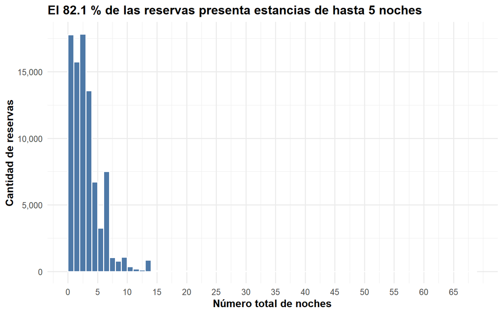

Distribución del número total de noches por reserva

```r
ggplot(
  hotel_limpio,
  aes(x = total_nights)
) +
  geom_histogram(
    binwidth = 1,
    boundary = 0,
    fill = "#4E79A7",
    color = "white"
  ) +
  scale_x_continuous(
    breaks = seq(
      0,
      max(
        hotel_limpio$total_nights,
        na.rm = TRUE
      ),
      5
    )
  ) +
  scale_y_continuous(
    labels = comma
  ) +
  labs(
    title = sprintf(
      "El %.1f %% de las reservas presenta estancias de hasta 5 noches",
      porcentaje_hasta_5
    ),
    x = "Número total de noches",
    y = "Cantidad de reservas"
  ) +
  theme_minimal(base_size = 12) +
  theme(
    plot.title = element_text(face = "bold"),
    axis.title = element_text(face = "bold")
  )
```

## Reservas con niños o bebés

```r
tabla_menores <- hotel_limpio |>
  filter(
    !is.na(con_menores)
  ) |>
  count(
    con_menores,
    name = "Reservas"
  ) |>
  mutate(
    Proporción = Reservas / sum(Reservas),
    Porcentaje = round(Proporción * 100, 1)
  )

kable(
  tabla_menores |>
    select(
      `Composición de la reserva` = con_menores,
      Reservas,
      Porcentaje
    ),
  caption = "Reservas según presencia de niños o bebés"
)
```

Reservas según presencia de niños o bebés

| Composición de la reserva | Reservas | Porcentaje |
| --- | --- | --- |
| Sin niños/bebés | 78123 | 89.6 |
| Con niños/bebés | 9103 | 10.4 |

Las reservas que incluyen niños o bebés representan aproximadamente **10.4 %** de los registros con información disponible sobre esta característica.

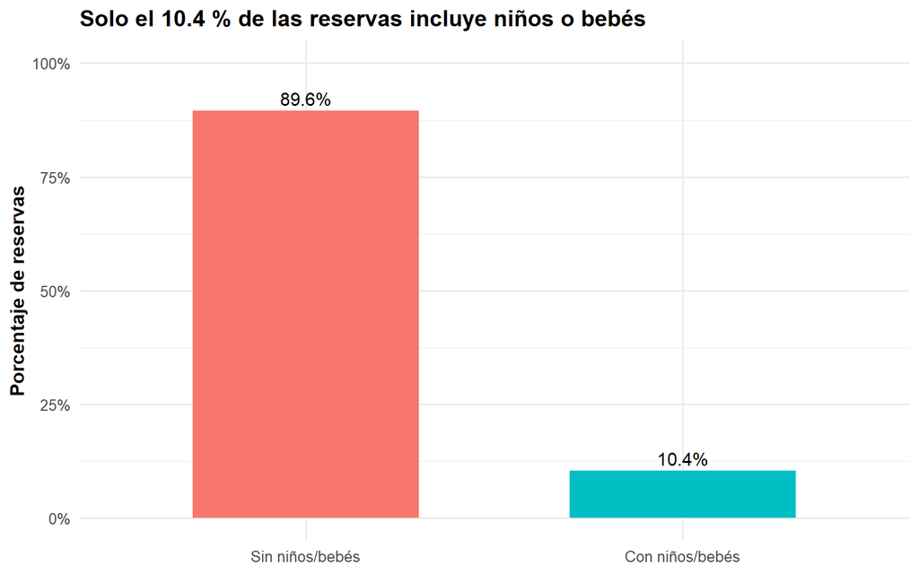

Proporción de reservas con y sin niños o bebés

```r
ggplot(
  tabla_menores,
  aes(
    x = con_menores,
    y = Proporción,
    fill = con_menores
  )
) +
  geom_col(
    width = 0.6,
    show.legend = FALSE
  ) +
  geom_text(
    aes(
      label = percent(
        Proporción,
        accuracy = 0.1
      )
    ),
    vjust = -0.4,
    size = 4
  ) +
  scale_fill_manual(
    values = c(
      "Sin niños/bebés" = "#F8766D",
      "Con niños/bebés" = "#00BFC4"
    )
  ) +
  scale_y_continuous(
    labels = percent_format(accuracy = 1),
    limits = c(0, 1)
  ) +
  labs(
    title = sprintf(
      "Solo el %.1f %% de las reservas incluye niños o bebés",
      tabla_menores$Porcentaje[
        tabla_menores$con_menores == "Con niños/bebés"
      ]
    ),
    x = NULL,
    y = "Porcentaje de reservas"
  ) +
  theme_minimal(base_size = 12) +
  theme(
    plot.title = element_text(face = "bold"),
    axis.title = element_text(face = "bold")
  )
```

## Valores atípicos

Para identificar posibles valores atípicos se utilizó el criterio del rango intercuartílico (IQR). Un valor atípico no se considera automáticamente un error; por ello, los casos identificados se conservaron para revisión.

```r
detectar_atipicos <- function(x) {

  q1 <- quantile(
    x,
    0.25,
    na.rm = TRUE
  )

  q3 <- quantile(
    x,
    0.75,
    na.rm = TRUE
  )

  iqr <- q3 - q1

  limite_inferior <- q1 - 1.5 * iqr
  limite_superior <- q3 + 1.5 * iqr

  sum(
    x < limite_inferior |
      x > limite_superior,
    na.rm = TRUE
  )
}

tabla_atipicos <- tibble(
  Variable = c(
    "Anticipación de la reserva",
    "Noches totales",
    "Tarifa diaria promedio"
  ),

  `Posibles valores atípicos` = c(
    detectar_atipicos(hotel_limpio$lead_time),
    detectar_atipicos(hotel_limpio$total_nights),
    detectar_atipicos(hotel_limpio$adr)
  ),

  Mínimo = c(
    min(hotel_limpio$lead_time, na.rm = TRUE),
    min(hotel_limpio$total_nights, na.rm = TRUE),
    min(hotel_limpio$adr, na.rm = TRUE)
  ),

  Máximo = c(
    max(hotel_limpio$lead_time, na.rm = TRUE),
    max(hotel_limpio$total_nights, na.rm = TRUE),
    max(hotel_limpio$adr, na.rm = TRUE)
  )
)

kable(
  tabla_atipicos,
  caption = "Posibles valores atípicos según el criterio IQR"
)
```

Posibles valores atípicos según el criterio IQR

| Variable | Posibles valores atípicos | Mínimo | Máximo |
| --- | --- | --- | --- |
| Anticipación de la reserva | 2394 | 0.00 | 737 |
| Noches totales | 2991 | 0.00 | 69 |
| Tarifa diaria promedio | 2508 | -6.38 | 5400 |

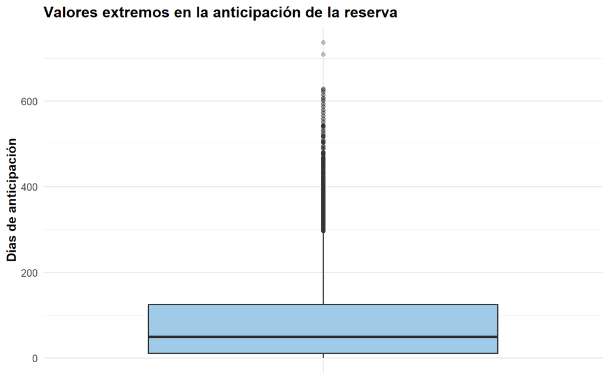

Valores extremos en la anticipación de la reserva

```r
ggplot(
  hotel_limpio,
  aes(
    x = "",
    y = lead_time
  )
) +
  geom_boxplot(
    fill = "#A0CBE8",
    outlier.alpha = 0.3
  ) +
  labs(
    title = "Valores extremos en la anticipación de la reserva",
    x = NULL,
    y = "Días de anticipación"
  ) +
  theme_minimal(base_size = 12) +
  theme(
    plot.title = element_text(face = "bold"),
    axis.text.x = element_blank(),
    axis.ticks.x = element_blank(),
    axis.title = element_text(face = "bold")
  )
```

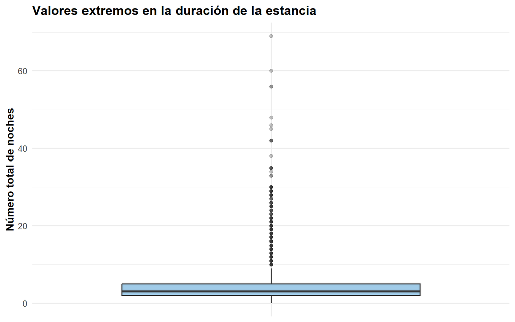

Valores extremos en la duración de la estancia

```r
ggplot(
  hotel_limpio,
  aes(
    x = "",
    y = total_nights
  )
) +
  geom_boxplot(
    fill = "#A0CBE8",
    outlier.alpha = 0.3
  ) +
  labs(
    title = "Valores extremos en la duración de la estancia",
    x = NULL,
    y = "Número total de noches"
  ) +
  theme_minimal(base_size = 12) +
  theme(
    plot.title = element_text(face = "bold"),
    axis.text.x = element_blank(),
    axis.ticks.x = element_blank(),
    axis.title = element_text(face = "bold")
  )
```

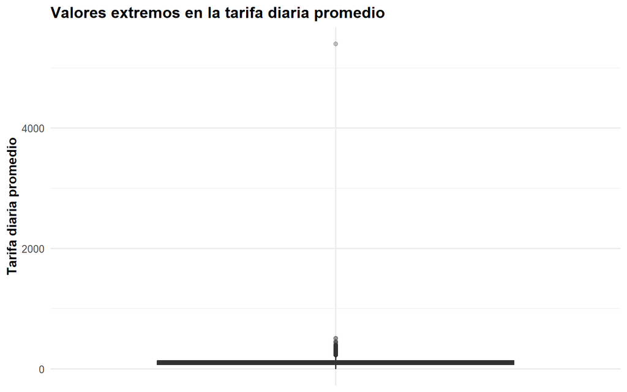

Valores extremos en la tarifa diaria promedio

```r
ggplot(
  hotel_limpio,
  aes(
    x = "",
    y = adr
  )
) +
  geom_boxplot(
    fill = "#A0CBE8",
    outlier.alpha = 0.3
  ) +
  labs(
    title = "Valores extremos en la tarifa diaria promedio",
    x = NULL,
    y = "Tarifa diaria promedio"
  ) +
  theme_minimal(base_size = 12) +
  theme(
    plot.title = element_text(face = "bold"),
    axis.text.x = element_blank(),
    axis.ticks.x = element_blank(),
    axis.title = element_text(face = "bold")
  )
```

En particular, `adr` presenta un valor mínimo de **-6.38**, previamente identificado como un problema de validez que requiere revisión.

## Duración de estancia según tipo de hotel

```r
resumen_estancia_hotel <- hotel_limpio |>
  group_by(hotel) |>
  summarise(
    Reservas = n(),
    `Media de noches` = round(mean(total_nights), 2),
    `Mediana de noches` = median(total_nights),
    Q1 = quantile(total_nights, 0.25),
    Q3 = quantile(total_nights, 0.75),
    .groups = "drop"
  )

kable(
  resumen_estancia_hotel,
  caption = "Duración de la estancia según tipo de hotel"
)
```

Duración de la estancia según tipo de hotel

| hotel | Reservas | Media de noches | Mediana de noches | Q1 | Q3 |
| --- | --- | --- | --- | --- | --- |
| City Hotel | 53274 | 3.14 | 3 | 2 | 4 |
| Resort Hotel | 33956 | 4.39 | 4 | 2 | 7 |

Las reservas de **Resort Hotel** presentan estancias más prolongadas que las de **City Hotel**. Resort Hotel registra una media de **4.39 noches**, mientras que City Hotel registra **3.14 noches**.

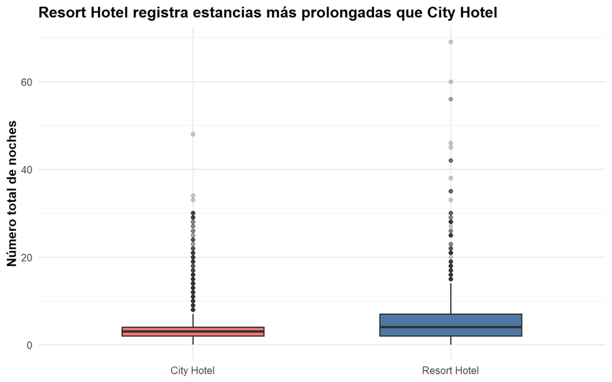

Duración de la estancia según tipo de hotel

```r
ggplot(
  hotel_limpio,
  aes(
    x = hotel,
    y = total_nights,
    fill = hotel
  )
) +
  geom_boxplot(
    width = 0.55,
    outlier.alpha = 0.25,
    show.legend = FALSE
  ) +
  scale_fill_manual(
    values = c(
      "City Hotel" = "#F8766D",
      "Resort Hotel" = "#4E79A7"
    )
  ) +
  labs(
    title = "Resort Hotel registra estancias más prolongadas que City Hotel",
    x = NULL,
    y = "Número total de noches"
  ) +
  theme_minimal(base_size = 12) +
  theme(
    plot.title = element_text(face = "bold"),
    axis.title = element_text(face = "bold")
  )
```

## Cancelaciones según tipo de hotel y presencia de menores

```r
resumen_cancelacion <- hotel_limpio |>
  filter(
    !is.na(con_menores)
  ) |>
  mutate(
    con_menores = factor(
      con_menores,
      levels = c(
        "Con niños/bebés",
        "Sin niños/bebés"
      )
    )
  ) |>
  group_by(
    hotel,
    con_menores
  ) |>
  summarise(
    Reservas = n(),
    Canceladas = sum(
      is_canceled == "Sí"
    ),
    `Tasa de cancelación` =
      Canceladas / Reservas,
    .groups = "drop"
  )

tabla_cancelacion <- resumen_cancelacion |>
  mutate(
    `Tasa de cancelación (%)` =
      round(
        `Tasa de cancelación` * 100,
        2
      )
  ) |>
  select(
    Hotel = hotel,
    `Tipo de reserva` = con_menores,
    `Tasa de cancelación (%)`
  )

kable(
  tabla_cancelacion,
  caption = "Cancelaciones según tipo de hotel y presencia de menores"
)
```

Cancelaciones según tipo de hotel y presencia de menores

| Hotel | Tipo de reserva | Tasa de cancelación (%) |
| --- | --- | --- |
| City Hotel | Con niños/bebés | 33.51 |
| City Hotel | Sin niños/bebés | 29.72 |
| Resort Hotel | Con niños/bebés | 35.25 |
| Resort Hotel | Sin niños/bebés | 21.97 |

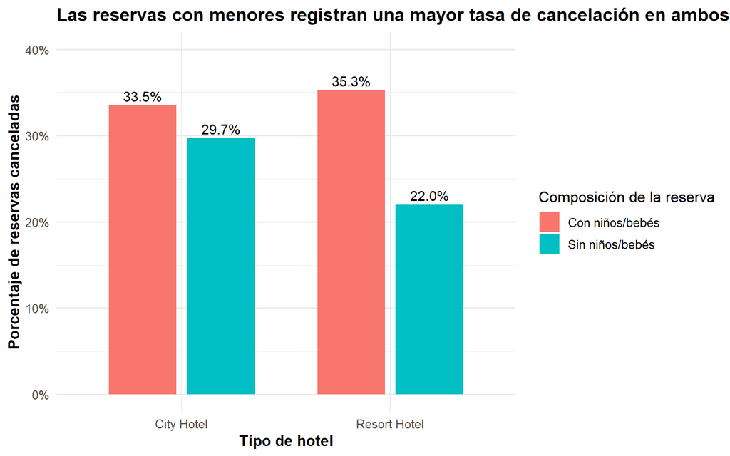

Tasa de cancelación según hotel y presencia de niños o bebés

```r
ggplot(
  resumen_cancelacion,
  aes(
    x = hotel,
    y = `Tasa de cancelación`,
    fill = con_menores
  )
) +
  geom_col(
    position = position_dodge(width = 0.75),
    width = 0.65
  ) +
  geom_text(
    aes(
      label = percent(
        `Tasa de cancelación`,
        accuracy = 0.1
      )
    ),
    position = position_dodge(width = 0.75),
    vjust = -0.4,
    size = 3.8
  ) +
  scale_fill_manual(
    values = c(
      "Con niños/bebés" = "#F8766D",
      "Sin niños/bebés" = "#00BFC4"
    )
  ) +
  scale_y_continuous(
    labels = percent_format(accuracy = 1),
    limits = c(0, 0.40)
  ) +
  labs(
    title = "Las reservas con menores registran una mayor tasa de cancelación en ambos hoteles",
    x = "Tipo de hotel",
    y = "Porcentaje de reservas canceladas",
    fill = "Composición de la reserva"
  ) +
  theme_minimal(base_size = 12) +
  theme(
    plot.title = element_text(face = "bold"),
    axis.title = element_text(face = "bold")
  )
```

La comparación muestra una **asociación descriptiva** entre la presencia de menores y una mayor proporción de cancelaciones en ambos hoteles. Este resultado no implica causalidad.

## Perfil de las reservas con niños o bebés

```r
reservas_menores <- hotel_limpio |>
  filter(
    con_menores == "Con niños/bebés"
  )

perfil_menores <- reservas_menores |>
  summarise(
    Reservas = n(),
    `Media de noches` = round(
      mean(total_nights),
      2
    ),
    `Mediana de noches` = median(
      total_nights
    ),
    `Promedio de adultos` = round(
      mean(adults),
      2
    ),
    `% clientes Transient` = round(
      mean(
        customer_type == "Transient"
      ) * 100,
      2
    ),
    `% reservas canceladas` = round(
      mean(
        is_canceled == "Sí"
      ) * 100,
      2
    )
  )

hotel_menores <- reservas_menores |>
  count(
    hotel,
    name = "Reservas"
  ) |>
  mutate(
    Porcentaje = round(
      Reservas / sum(Reservas) * 100,
      2
    )
  )

kable(
  perfil_menores,
  caption = "Características de las reservas con niños o bebés"
)
```

Características de las reservas con niños o bebés

| Reservas | Media de noches | Mediana de noches | Promedio de adultos | % clientes Transient | % reservas canceladas |
| --- | --- | --- | --- | --- | --- |
| 9103 | 3.94 | 3 | 1.96 | 90.86 | 34.25 |

```r
kable(
  hotel_menores,
  caption = "Distribución de las reservas con menores según tipo de hotel"
)
```

Distribución de las reservas con menores según tipo de hotel

| hotel | Reservas | Porcentaje |
| --- | --- | --- |
| City Hotel | 5234 | 57.5 |
| Resort Hotel | 3869 | 42.5 |

Se identificaron **9103 reservas con niños y/o bebés**. La estancia promedio es de **3.94 noches**, con aproximadamente **1.96 adultos por reserva**. El tipo de cliente predominante es `Transient`.

## Evolución temporal de las reservas

```r
reservas_mes <- hotel_limpio |>
  count(
    periodo,
    hotel,
    name = "reservas"
  )

resumen_temporal <- reservas_mes |>
  group_by(hotel) |>
  summarise(
    mes_maximo =
      periodo[which.max(reservas)],
    max_reservas =
      max(reservas),
    .groups = "drop"
  )

comparacion_mensual <- reservas_mes |>
  pivot_wider(
    names_from = hotel,
    values_from = reservas,
    values_fill = 0
  ) |>
  summarise(
    meses_observados = n(),
    meses_city_superior = sum(
      `City Hotel` > `Resort Hotel`
    )
  )

picos_reservas <- reservas_mes |>
  group_by(hotel) |>
  slice_max(
    reservas,
    n = 1,
    with_ties = FALSE
  ) |>
  ungroup()

kable(
  resumen_temporal,
  caption = "Mes de mayor cantidad de reservas por tipo de hotel"
)
```

Mes de mayor cantidad de reservas por tipo de hotel

| hotel | mes_maximo | max_reservas |
| --- | --- | --- |
| City Hotel | 2017-05-01 | 3062 |
| Resort Hotel | 2017-08-01 | 1713 |

City Hotel registra una mayor cantidad de reservas que Resort Hotel en **23 de los 26 meses observados**.

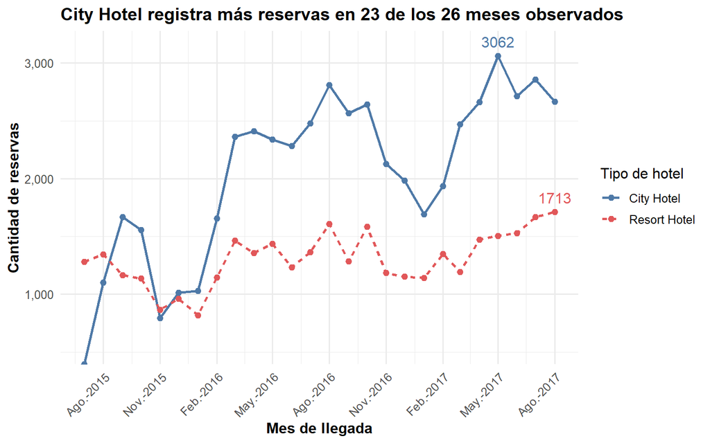

Evolución mensual de las reservas según tipo de hotel

```r
titulo_temporal <- sprintf(
  "City Hotel registra más reservas en %d de los %d meses observados",
  comparacion_mensual$meses_city_superior,
  comparacion_mensual$meses_observados
)

ggplot(
  reservas_mes,
  aes(
    x = periodo,
    y = reservas,
    color = hotel,
    linetype = hotel
  )
) +
  geom_line(linewidth = 1) +
  geom_point(size = 2) +
  geom_text(
    data = picos_reservas,
    aes(label = reservas),
    vjust = -0.8,
    show.legend = FALSE
  ) +
  scale_color_manual(
    values = c(
      "City Hotel" = "#4E79A7",
      "Resort Hotel" = "#E15759"
    )
  ) +
  scale_x_date(
    date_breaks = "3 months",
    date_labels = "%b-%Y"
  ) +
  scale_y_continuous(
    labels = comma,
    expand = expansion(
      mult = c(0, 0.08)
    )
  ) +
  labs(
    title = titulo_temporal,
    x = "Mes de llegada",
    y = "Cantidad de reservas",
    color = "Tipo de hotel",
    linetype = "Tipo de hotel"
  ) +
  theme_minimal(base_size = 12) +
  theme(
    plot.title = element_text(face = "bold"),
    axis.title = element_text(face = "bold"),
    axis.text.x = element_text(
      angle = 45,
      hjust = 1
    )
  )
```

Debido a que el dataset comienza en julio de 2015 y finaliza en agosto de 2017, no se comparan totales anuales completos entre 2015, 2016 y 2017.

# Respuesta a las preguntas analíticas

## Pregunta analítica 1

**¿Cómo se distribuye y compara la duración total de la estancia entre las reservas de City Hotel y Resort Hotel?**

Las reservas de Resort Hotel presentan estancias más prolongadas. Resort Hotel registra una media de **4.39 noches** y una mediana de **4 noches**, mientras que City Hotel presenta una media de **3.14 noches** y una mediana de **3 noches**.

## Pregunta analítica 2

**¿Qué características presentan las reservas con niños y/o bebés en relación con el tipo de hotel, duración de estancia, cantidad de adultos, tipo de cliente y cancelación?**

Las reservas con niños o bebés representan aproximadamente el **10.4 %** de las reservas con información disponible sobre esta característica. Presentan una estancia promedio cercana a **3.94 noches**, alrededor de **1.96 adultos por reserva** y una alta presencia de clientes `Transient`. Además, se observa una mayor proporción de cancelaciones en las reservas con menores que en las reservas sin menores en ambos tipos de hotel.

# Hallazgos principales

1. **El 82.1 % de las reservas presenta estancias de hasta 5 noches**, por lo que las estancias cortas constituyen el comportamiento más frecuente.
2. **Resort Hotel registra estancias más prolongadas que City Hotel**, tanto en promedio como en mediana.
3. **Solo alrededor del 10.4 % de las reservas incluye niños o bebés**, por lo que las reservas familiares representan un segmento menor del conjunto analizado.
4. **Las reservas con menores presentan una mayor tasa de cancelación en ambos hoteles** que las reservas sin menores.
5. **City Hotel registra más reservas en 23 de los 26 meses observados**.

# Conclusiones

- Las reservas hoteleras se concentran principalmente en estancias cortas.
- Resort Hotel presenta estancias promedio y medianas superiores a las observadas en City Hotel.
- Las reservas con niños o bebés representan aproximadamente una décima parte de los registros con información disponible sobre esta característica y se caracterizan por una estancia cercana a cuatro noches y aproximadamente dos adultos por reserva.
- Las reservas con menores presentan una mayor proporción de cancelaciones en ambos hoteles; este resultado corresponde a una asociación descriptiva y no implica causalidad.
- City Hotel concentra una mayor cantidad de reservas durante la mayoría de los meses observados.

# Recomendaciones

1. Considerar las diferencias en la duración de las estancias entre City Hotel y Resort Hotel al planificar recursos operativos, disponibilidad de habitaciones y servicios asociados a la permanencia de los huéspedes.
2. Realizar un seguimiento específico de las reservas que incluyen niños o bebés, especialmente respecto a las cancelaciones, con el fin de identificar oportunidades para mejorar la gestión de este segmento.

# Bibliografía

- Datos.gob.es. (2021). *Guía práctica de introducción al análisis exploratorio de datos en R*. Gobierno de España.
- Posit Software, PBC. (2024). *Transformación de datos con dplyr: guía rápida* [Hoja de referencia].
- Posit Software, PBC. (2024). *Visualización de datos con ggplot2: guía rápida* [Hoja de referencia].
- Wickham, H., & Grolemund, G. (2023). *R para ciencia de datos* [Versión en español].